# Análisis de Enriquecimiento y Subredes con pathfindR

Cruz Sancén, N.A.

2026-07-23

> **Nota de autoría:** Este documento es una adaptación y traducción libre del tutorial original *“Introduction to pathfindR”* escrito por Ege Ulgen (2019). Las referencias formales al paquete se encuentran al final del documento.

## 1. Hablemos de Redes: Conceptos Básicos

Antes de meternos a tirar código, es súper importante entender de qué hablamos cuando decimos “red”. Piensa en una red (o grafo) como un mapa que nos ayuda a visualizar cómo se conectan diferentes cosas entre sí.

Toda red en su forma más básica está compuesta por dos cosas:

- **Nodos (o vértices):** Son los protagonistas de nuestra historia. En biología, un nodo puede ser un gen, una proteína, un metabolito o hasta una enfermedad.
- **Aristas (o enlaces):** Son las líneas que conectan a los nodos. Representan la relación entre ellos. Por ejemplo, una interacción física entre dos proteínas o una reacción enzimática.

### Tipos de redes

No todas las conexiones son iguales. Dependiendo de cómo fluye la información, tenemos: * **Redes no dirigidas:** La conexión es mutua y no tiene un sentido específico. Piensa en Facebook: si somos amigos, la conexión va en ambos sentidos. En biología, una red de interacción proteína-proteína (PIN) suele ser no dirigida (la proteína A toca a la proteína B y viceversa). * **Redes dirigidas:** La conexión tiene una dirección clara, como una flecha. Piensa en Twitter/X: yo te puedo seguir, pero tú no necesariamente a mí. En sistemas biológicos, las redes metabólicas o de señalización son dirigidas (la enzima A produce el metabolito B, pero el flujo no va al revés).

### El Grado y su Distribución

El **grado** de un nodo es simplemente el número de conexiones que tiene. Si una proteína interactúa con otras 5, su grado es 5.

La **distribución de grado** nos dice cómo se reparten estas conexiones en toda la red. En la mayoría de las redes biológicas, vemos algo llamado distribución “libre de escala” (*scale-free*). Esto significa que la gran mayoría de los nodos tienen muy pocas conexiones, pero existen unos cuantos nodos súper conectados llamados **hubs** (como si fueran los “influencers” de la célula). El gen *TP53* es un clásico ejemplo de un hub biológico: si falla, toda la red se desestabiliza.

## 2. Preparación del Entorno

Vamos a asegurarnos de tener todo lo necesario para correr `pathfindR`. Este bloque de código revisará si ya tienes las librerías instaladas en tu computadora; si te falta alguna, la instalará automáticamente antes de cargarla.

```r
# 1. Instalar BiocManager si no lo tienes (la llave para entrar a Bioconductor)
if (!requireNamespace("BiocManager", quietly = TRUE)) {
  install.packages("BiocManager")
}

# 2. Instalar el paquete rebelde ggkegg desde Bioconductor
if (!requireNamespace("ggkegg", quietly = TRUE)) {
  BiocManager::install("ggkegg", ask = FALSE)
}

# 3. Definir y revisar los paquetes estándar de CRAN
paquetes_requeridos <- c("pathfindR", "knitr", "ggplot2")
paquetes_faltantes <- paquetes_requeridos[!(paquetes_requeridos %in% installed.packages()[,"Package"])]

if(length(paquetes_faltantes) > 0) {
  install.packages(paquetes_faltantes, dependencies = TRUE)
}

# 4. Cargar las librerías al entorno (asegurando saltos de línea)
library(pathfindR)
library(knitr)
library(ggplot2)

print("¡Todas las librerías cargadas con éxito!")
```

```
## [1] "¡Todas las librerías cargadas con éxito!"
```

## 3. ¿Por qué usar pathfindR?

La idea que motivó el desarrollo de `pathfindR` es muy sencilla: hacer un análisis de enriquecimiento usando solo una lista de genes diferencialmente expresados (por ejemplo, los que te salen de un RNA-seq) a veces te deja la foto a la mitad. Una lista plana de genes no te explica muy bien los mecanismos detrás de una enfermedad.

Por eso, esta herramienta toma tus genes y los cruza con una **Red de Interacción Proteína-Proteína (PIN)**. El objetivo es buscar **subredes activas**: grupitos de genes fuertemente interconectados donde la mayoría están significativamente alterados en tu experimento. Así, en lugar de genes aislados, encuentras módulos enteros asociados a la enfermedad.

### Los datos de ejemplo

Vamos a usar unos datos de prueba que ya vienen en el paquete (`example_pathfindR_input`). Son genes diferencialmente expresados de un estudio (GSE15573) que comparó pacientes con artritis reumatoide vs personas sanas.

```r
# Vistazo rápido a los primeros 6 renglones
kable(head(example_pathfindR_input))
```

| Gene.symbol | logFC | adj.P.Val |
| --- | --- | --- |
| FAM110A | -0.6939359 | 0.0000034 |
| RNASE2 | 1.3535040 | 0.0000101 |
| S100A8 | 1.5448338 | 0.0000347 |
| S100A9 | 1.0280904 | 0.0002263 |
| TEX261 | -0.3235994 | 0.0002263 |
| ARHGAP17 | -0.6919330 | 0.0002708 |

## 4. Análisis de Enriquecimiento (El flujo principal)

La herramienta nos facilita la vida con una sola función maestra llamada `run_pathfindR()`. Tu tabla de entrada solo necesita tener estas columnas: **Símbolos de los genes**, **Valores de cambio (logFC - opcional pero recomendado)** y **Valores p**.

Para correr el análisis con la configuración por defecto:

```r
# Ojo: este paso suele tardar un par de minutos porque hace muchas simulaciones
output_df <- run_pathfindR(example_pathfindR_input)
```

```
## ## Testing input
```

```
## The input looks OK
```

```
## ## Processing input. Converting gene symbols,
##           if necessary (and if human gene symbols provided)
```

```
## Number of genes provided in input: 572
```

```
## Number of genes in input after p-value filtering: 572
```

```
## Could not find any interactions for 1 (0.17%) genes in the PIN
```

```
## Final number of genes in input: 571
```

```
## ## Performing Active Subnetwork Search and Enrichment
```

```
## ## Building network (once for all iterations)
```

```
## ## Processing the enrichment results over all iterations
```

```
## ## Annotating involved genes and visualizing enriched terms
```

```
## Plotting the enrichment bubble chart
```

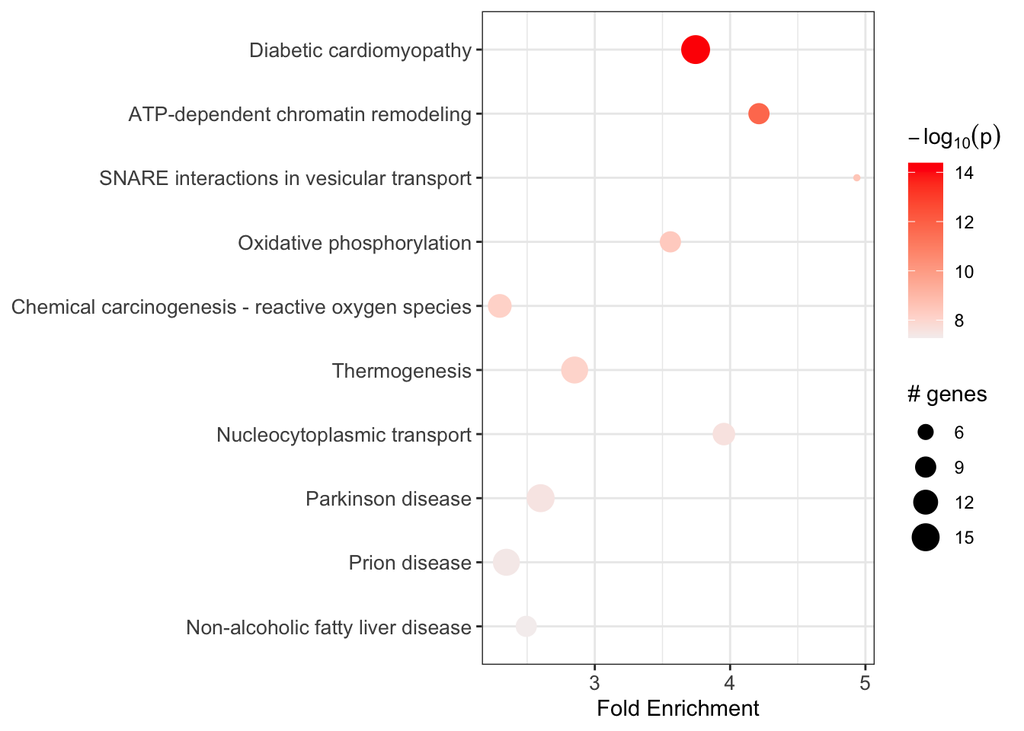

```
## Found 138 enriched terms
```

```
## You may run:
```

```
## - cluster_enriched_terms() for clustering enriched terms
```

```
## - visualize_terms() for visualizing enriched term diagrams
```

### Personalizando el análisis

Si quieres meterle mano a los parámetros, la función es súper flexible:

**1. Cambiar el umbral del Valor p** Por defecto usa p < 0.05, pero si quieres ser más estricto:

```r
output_df <- run_pathfindR(example_pathfindR_input, p_val_threshold = 0.01)
```

```
## ## Testing input
```

```
## The input looks OK
```

```
## ## Processing input. Converting gene symbols,
##           if necessary (and if human gene symbols provided)
```

```
## Number of genes provided in input: 572
```

```
## Number of genes in input after p-value filtering: 211
```

```
## Could not find any interactions for 1 (0.47%) genes in the PIN
```

```
## Final number of genes in input: 210
```

```
## ## Performing Active Subnetwork Search and Enrichment
```

```
## ## Building network (once for all iterations)
```

```
## ## Processing the enrichment results over all iterations
```

```
## ## Annotating involved genes and visualizing enriched terms
```

```
## Plotting the enrichment bubble chart
```

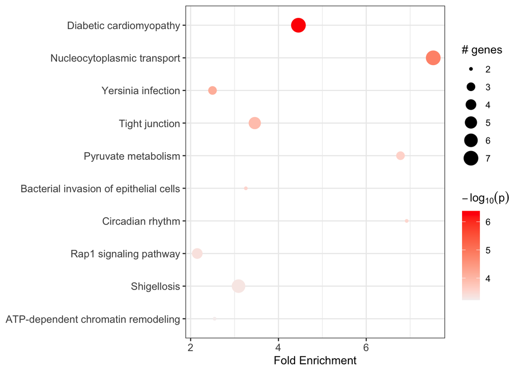

```
## Found 59 enriched terms
```

```
## You may run:
```

```
## - cluster_enriched_terms() for clustering enriched terms
```

```
## - visualize_terms() for visualizing enriched term diagrams
```

**2. Guardar resultados en una carpeta específica** Para no ensuciar tu directorio de trabajo, puedes mandarlo todo a una carpeta nueva:

```r
output_df <- run_pathfindR(example_pathfindR_input, output_dir = "resultados_artritis")
```

```
## ## Testing input
```

```
## The input looks OK
```

```
## ## Processing input. Converting gene symbols,
##           if necessary (and if human gene symbols provided)
```

```
## Number of genes provided in input: 572
```

```
## Number of genes in input after p-value filtering: 572
```

```
## Could not find any interactions for 1 (0.17%) genes in the PIN
```

```
## Final number of genes in input: 571
```

```
## ## Performing Active Subnetwork Search and Enrichment
```

```
## ## Building network (once for all iterations)
```

```
## ## Processing the enrichment results over all iterations
```

```
## ## Annotating involved genes and visualizing enriched terms
```

```
## ## Creating HTML report
```

```
##
##
## processing file: results.Rmd
```

[output not shown]

```
## output file: results.knit.md
```

[output not shown]

```
##
## Output created: resultados_artritis/results.html
```

```
##
##
## processing file: enriched_terms.Rmd
```

[output not shown]

```
## output file: enriched_terms.knit.md
```

[output not shown]

```
##
## Output created: resultados_artritis/enriched_terms.html
```

```
##
##
## processing file: conversion_table.Rmd
```

[output not shown]

```
## output file: conversion_table.knit.md
```

[output not shown]

```
##
## Output created: resultados_artritis/conversion_table.html
```

```
## Plotting the enrichment bubble chart
```

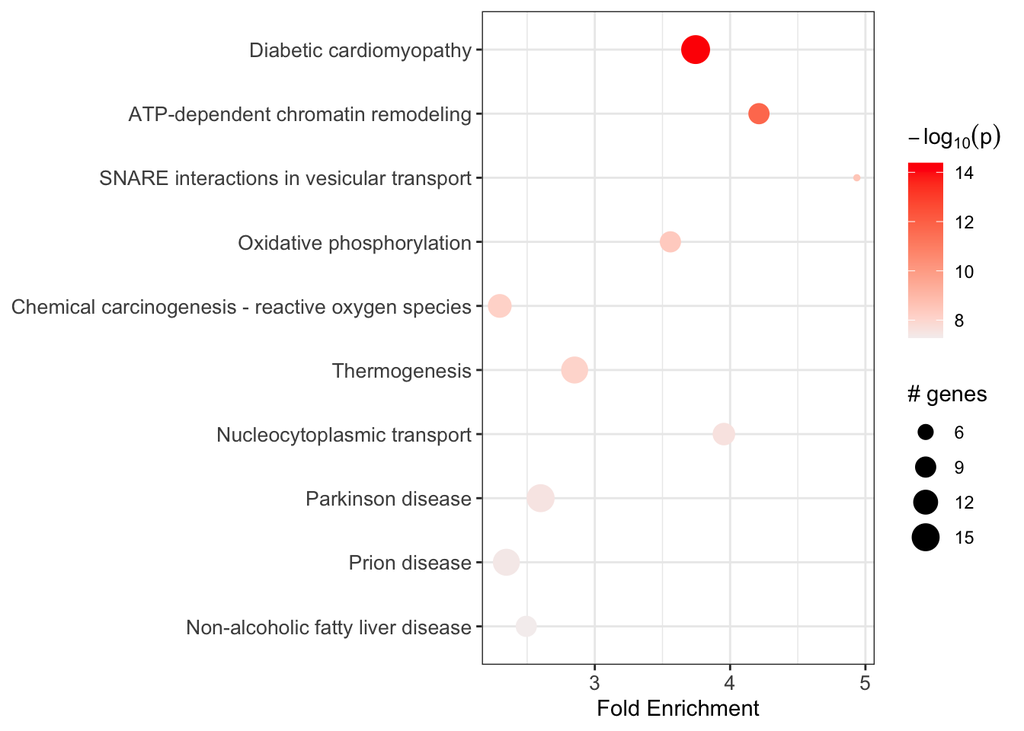

```
## Found 138 enriched terms
```

```
## You may run:
```

```
## - cluster_enriched_terms() for clustering enriched terms
```

```
## - visualize_terms() for visualizing enriched term diagrams
```

**3. Elegir la base de datos (Gene Sets)** Por defecto usa las vías de KEGG, pero puedes cambiarlo a Reactome, BioCarta, o Gene Ontology (GO-All, GO-BP, GO-CC, GO-MF):

```r
output_df <- run_pathfindR(example_pathfindR_input, gene_sets = "GO-BP")
```

```
## ## Testing input
```

```
## The input looks OK
```

```
## ## Processing input. Converting gene symbols,
##           if necessary (and if human gene symbols provided)
```

```
## Number of genes provided in input: 572
```

```
## Number of genes in input after p-value filtering: 572
```

```
## Could not find any interactions for 1 (0.17%) genes in the PIN
```

```
## Final number of genes in input: 571
```

```
## ## Performing Active Subnetwork Search and Enrichment
```

```
## ## Building network (once for all iterations)
```

```
## ## Processing the enrichment results over all iterations
```

```
## ## Annotating involved genes and visualizing enriched terms
```

```
## Plotting the enrichment bubble chart
```

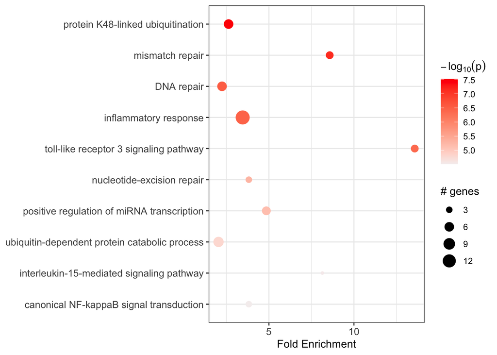

```
## Found 84 enriched terms
```

```
## You may run:
```

```
## - cluster_enriched_terms() for clustering enriched terms
```

```
## - visualize_terms() for visualizing enriched term diagrams
```

**4. Cambiar la red de interacciones (PIN)** Por defecto usa Biogrid, pero si prefieres otra red como STRING o IntAct:

```r
output_df <- run_pathfindR(example_pathfindR_input, pin_name_path = "STRING")
```

```
## ## Testing input
```

```
## The input looks OK
```

```
## ## Processing input. Converting gene symbols,
##           if necessary (and if human gene symbols provided)
```

```
## Number of genes provided in input: 572
```

```
## Number of genes in input after p-value filtering: 572
```

```
## Could not find any interactions for 72 (12.59%) genes in the PIN
```

```
## Final number of genes in input: 500
```

```
## ## Performing Active Subnetwork Search and Enrichment
```

```
## ## Building network (once for all iterations)
```

```
## ## Processing the enrichment results over all iterations
```

```
## ## Annotating involved genes and visualizing enriched terms
```

```
## Plotting the enrichment bubble chart
```

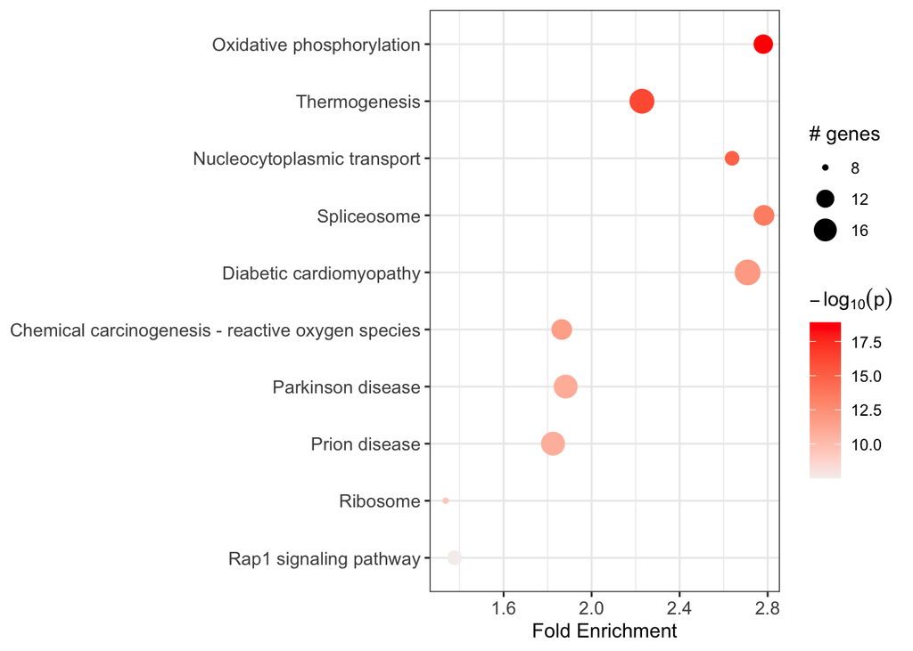

```
## Found 93 enriched terms
```

```
## You may run:
```

```
## - cluster_enriched_terms() for clustering enriched terms
```

```
## - visualize_terms() for visualizing enriched term diagrams
```

## 5. El Resultado del Análisis

La función te va a devolver un dataframe con los términos enriquecidos y te generará automáticamente una gráfica de burbujas con los 10 mejores resultados.

Las columnas clave que te devuelve son:

- **ID y Term_Description:** Qué vía o proceso biológico es.
- **Fold_Enrichment:** Qué tan enriquecido está.
- **lowest_p / highest_p:** El valor p ajustado más alto y bajo encontrado durante las simulaciones.
- **Up_regulated / Down_regulated:** Qué genes de tu lista original que están dentro de esa vía subieron o bajaron.

```r
# Ver los primeros 2 resultados
kable(head(example_pathfindR_output, 2))
```

| ID | Term_Description | Fold_Enrichment | occurrence | support | lowest_p | highest_p | Up_regulated | Down_regulated |
| --- | --- | --- | --- | --- | --- | --- | --- | --- |
| hsa05415 | Diabetic cardiomyopathy | 3.744993 | 10 | 0.0871034 | 0 | 0.000000 | NCF4, NDUFA1, NDUFB3, UQCRQ, COX6A1, COX7A2, COX7C, MMP9, GAPDH | SLC25A5, VDAC1, ATP2A2, MTOR, PDHA1, PDHB, PARP1 |
| hsa03082 | ATP-dependent chromatin remodeling | 4.213117 | 10 | 0.0245786 | 0 | 0.000312 |  | ARID1A, SMARCA4, ACTB, ACTG1, BRD7, BRD9, HDAC1, EP400, TRRAP |

Además, te creará un reporte en HTML interactivo en tu carpeta de resultados, donde incluso te muestra qué genes tuvieron que ser “traducidos” a otros alias para que la red los reconociera.

## 6. Agrupando la información (Clustering)

A veces el análisis te arroja muchísimas vías que en el fondo hacen cosas muy parecidas. Para limpiar un poco la señal, podemos hacer un clustering de los resultados usando una métrica llamada *estadística Kappa* (básicamente, qué tanto se solapan los genes de dos vías distintas).

```r
# Agrupamiento jerárquico
output_clustered <- cluster_enriched_terms(example_pathfindR_output)
```

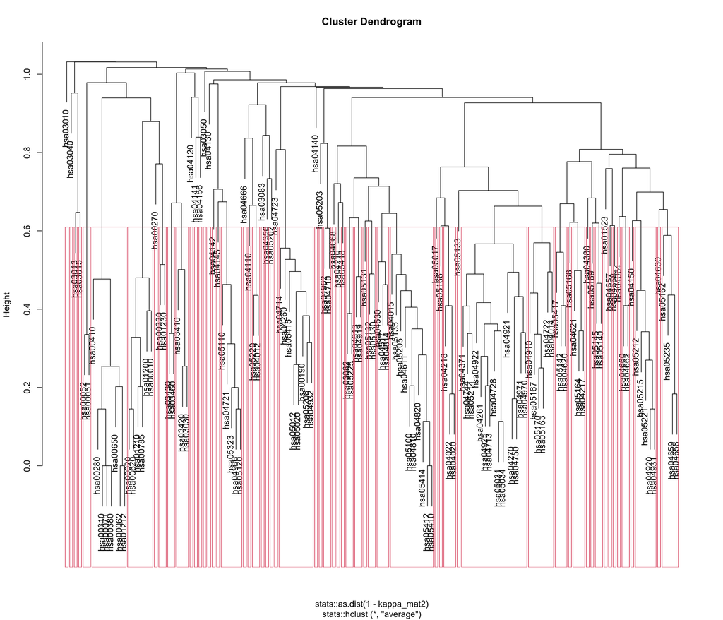

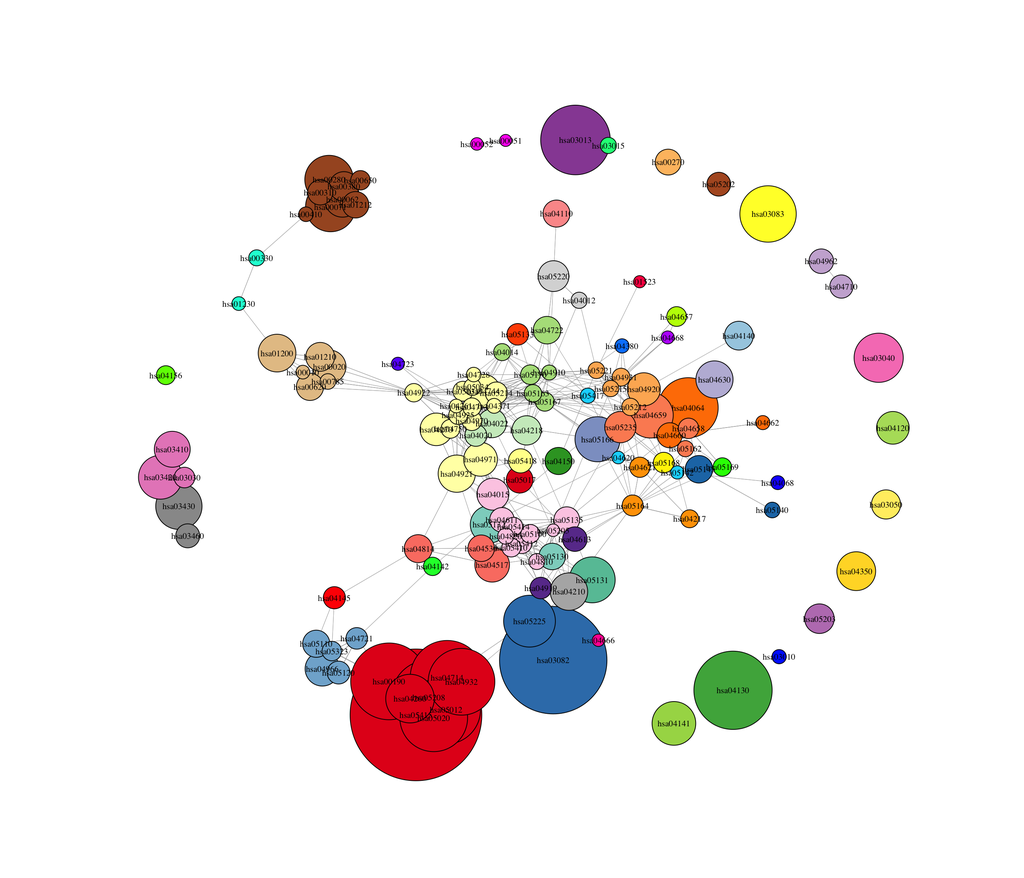

```r
# Ver los términos "representativos" (los líderes de cada cluster)
terminos_lideres <- output_clustered[output_clustered$Status == "Representative", ]
kable(terminos_lideres)
```

|  | ID | Term_Description | Fold_Enrichment | occurrence | support | lowest_p | highest_p | Up_regulated | Down_regulated | Cluster | Status |
| --- | --- | --- | --- | --- | --- | --- | --- | --- | --- | --- | --- |
| 1 | hsa05415 | Diabetic cardiomyopathy | 3.744993 | 10 | 0.0871034 | 0.0000000 | 0.0000000 | NCF4, NDUFA1, NDUFB3, UQCRQ, COX6A1, COX7A2, COX7C, MMP9, GAPDH | SLC25A5, VDAC1, ATP2A2, MTOR, PDHA1, PDHB, PARP1 | 1 | Representative |
| 2 | hsa03082 | ATP-dependent chromatin remodeling | 4.213117 | 10 | 0.0245786 | 0.0000000 | 0.0003120 |  | ARID1A, SMARCA4, ACTB, ACTG1, BRD7, BRD9, HDAC1, EP400, TRRAP | 2 | Representative |
| 3 | hsa04130 | SNARE interactions in vesicular transport | 4.936581 | 10 | 0.0338571 | 0.0000000 | 0.0000000 | STX6 | BET1L, SNAP23, STX2 | 3 | Representative |
| 7 | hsa03013 | Nucleocytoplasmic transport | 3.954058 | 10 | 0.0150067 | 0.0000000 | 0.0109558 | NUP214 | NUP62, NUP93, UBE2I, RANGAP1, SUMO3, EIF4A3, RNPS1, SRRM1, TNPO1 | 4 | Representative |
| 11 | hsa04064 | NF-kappa B signaling pathway | 3.194258 | 8 | 0.0176307 | 0.0000003 | 0.0004584 | LY96 | IKBKB, PRKCQ, CARD11, TICAM1, CSNK2A2, PARP1, UBE2I | 5 | Representative |
| 12 | hsa03083 | Polycomb repressive complex | 2.483341 | 10 | 0.0079062 | 0.0000007 | 0.0495676 | CBX3 | PHF19, RING1, KDM2B, HDAC1 | 6 | Representative |
| 14 | hsa00071 | Fatty acid degradation | 2.841404 | 1 | 0.0062893 | 0.0000034 | 0.0000034 |  | HADH, ECHS1, ALDH9A1 | 7 | Representative |
| 15 | hsa03040 | Spliceosome | 3.519600 | 10 | 0.0215057 | 0.0000043 | 0.0065228 | SF3B6, LSM3, BUD31 | SNRPB, SF3B2, U2AF2, PUF60, HNRNPA1, PCBP1, SRSF8, SRSF5, SNU13, DDX23, EIF4A3 | 8 | Representative |
| 18 | hsa03430 | Mismatch repair | 5.312191 | 10 | 0.0232130 | 0.0000088 | 0.0002342 |  | MLH1, POLD2, RPA1 | 9 | Representative |
| 19 | hsa05131 | Shigellosis | 3.030831 | 10 | 0.0235076 | 0.0000097 | 0.0022685 | TLR5, CBX3, RRAGD, HK3 | IKBKB, PRKCQ, ARF1, PIK3R4, MTOR, FNBP1, CRKL, ACTB, ACTG1, ITGB1, VDAC1, PFN1 | 10 | Representative |
| 20 | hsa04659 | Th17 cell differentiation | 3.393900 | 10 | 0.0079062 | 0.0000104 | 0.0094960 |  | IKBKB, PRKCQ, NFATC3, IL2RB, HLA-DPA1, MTOR, GATA3, IL27RA, JAK1 | 11 | Representative |
| 21 | hsa05166 | Human T-cell leukemia virus 1 infection | 2.568356 | 3 | 0.0057471 | 0.0000120 | 0.0058984 |  | NFATC3, IL2RB, JAK1, TRRAP, SLC25A5, VDAC1, ADCY7, CREB1, ANAPC1, IKBKB, SRF, ETS1, HLA-DPA1, ZFP36 | 12 | Representative |
| 22 | hsa03420 | Nucleotide excision repair | 3.284419 | 10 | 0.0120364 | 0.0000164 | 0.0304775 | GTF2H5, POLE4 | POLD2, RPA1, XPC | 13 | Representative |
| 23 | hsa04141 | Protein processing in endoplasmic reticulum | 1.480974 | 7 | 0.0065359 | 0.0000170 | 0.0153838 | DDIT3, CKAP4 | DDOST, EDEM1, UBE2G1, PDIA4 | 14 | Representative |
| 24 | hsa04350 | TGF-beta signaling pathway | 1.536860 | 2 | 0.0105927 | 0.0000582 | 0.0000582 |  | SMAD7, TGIF2, HDAC1, SIN3A | 15 | Representative |
| 25 | hsa01200 | Carbon metabolism | 2.883313 | 10 | 0.0462930 | 0.0000764 | 0.0005263 | GAPDH, HK3 | PDHA1, PDHB, MDH2, SHMT1, ECHS1, GOT1 | 16 | Representative |
| 26 | hsa04210 | Apoptosis | 2.111760 | 2 | 0.0133249 | 0.0000817 | 0.0000817 | DDIT3 | DFFB, IKBKB, FASLG, PARP1, ACTB, ACTG1 | 17 | Representative |
| 27 | hsa05132 | Salmonella infection | 2.503696 | 10 | 0.0396078 | 0.0000831 | 0.0037380 | TXN, GAPDH, LY96, TLR5, TLR6, DYNLT1, STX10 | IKBKB, ACTB, ACTG1, ARF1, PFN1, DYNC1H1, TUBB, RAB9A | 18 | Representative |
| 28 | hsa04921 | Oxytocin signaling pathway | 2.715120 | 10 | 0.0232130 | 0.0000863 | 0.0038116 | MYL6B, MYL6 | CALM1, CALM3, ADCY7, EEF2K, EEF2, ACTB, ACTG1, NFATC3 | 19 | Representative |
| 29 | hsa04630 | JAK-STAT signaling pathway | 1.463238 | 10 | 0.0064527 | 0.0000877 | 0.0338434 |  | JAK1, IL2RB, IL27RA, IL10RA, PIAS3, MTOR | 20 | Representative |
| 32 | hsa04517 | IgSF CAM signaling | 1.583020 | 5 | 0.0080000 | 0.0001646 | 0.0199713 | MYL6B, MYL6 | ACTB, ACTG1, TUBB, CNTNAP1, CD96, LCP2, ABL1, ITGB1, PRKCQ | 21 | Representative |
| 33 | hsa04966 | Collecting duct acid secretion | 4.525200 | 10 | 0.0160092 | 0.0001728 | 0.0001728 | ATP6V1D, ATP6V0E1 | ATP6V0E2 | 22 | Representative |
| 37 | hsa04920 | Adipocytokine signaling pathway | 1.770730 | 2 | 0.0052963 | 0.0002473 | 0.0002473 |  | PRKCQ, IKBKB, MTOR | 23 | Representative |
| 38 | hsa04120 | Ubiquitin mediated proteolysis | 1.783655 | 10 | 0.0193350 | 0.0002713 | 0.0439148 | TRIP12 | ANAPC1, PIAS3, UBE2G1, HERC1, UBE2I | 24 | Representative |
| 40 | hsa04015 | Rap1 signaling pathway | 2.174732 | 10 | 0.0075034 | 0.0003231 | 0.0132404 |  | RALGDS, EVL, PFN1, ACTB, ACTG1, ITGB1, CRKL, ADCY7, CALM1, CALM3, LCP2 | 25 | Representative |
| 42 | hsa05220 | Chronic myeloid leukemia | 2.143515 | 4 | 0.0113814 | 0.0004338 | 0.0146673 |  | ABL1, HDAC1, IKBKB, CRKL | 26 | Representative |
| 44 | hsa05203 | Viral carcinogenesis | 1.974633 | 10 | 0.0150067 | 0.0005840 | 0.0203628 | GTF2B | SCRIB, RBL2, CREB1, JAK1, SRF, DNAJA3, HDAC1 | 27 | Representative |
| 45 | hsa04218 | Cellular senescence | 2.088554 | 6 | 0.0075034 | 0.0006349 | 0.0350171 |  | MTOR, ETS1, RBL2, CALM1, CALM3, NFATC3, SLC25A5, VDAC1 | 28 | Representative |
| 46 | hsa03050 | Proteasome | 1.810080 | 10 | 0.0180547 | 0.0006553 | 0.0025872 |  | PSMD7, PSMB10 | 29 | Representative |
| 47 | hsa04140 | Autophagy - animal | 1.974633 | 2 | 0.0054377 | 0.0007165 | 0.0007165 | IGBP1, RRAGD | MTOR, WDR45B, PIK3R4, UVRAG, PRKCQ, GORASP2 | 30 | Representative |
| 51 | hsa05145 | Toxoplasmosis | 2.201448 | 2 | 0.0060583 | 0.0009824 | 0.0009824 | LY96 | IKBKB, JAK1, HLA-DPA1, ITGB1, IL10RA | 31 | Representative |
| 52 | hsa04722 | Neurotrophin signaling pathway | 3.106281 | 10 | 0.0176307 | 0.0009830 | 0.0233110 |  | CRKL, FASLG, SH2B3, ABL1, MAGED1, IRAK2, IKBKB, CALM1, CALM3 | 32 | Representative |
| 55 | hsa04150 | mTOR signaling pathway | 1.863317 | 5 | 0.0080000 | 0.0010852 | 0.0419242 | RRAGD, ATP6V1D | LPIN1, IKBKB, WDR59, MTOR, TELO2 | 33 | Representative |
| 56 | hsa04110 | Cell cycle | 1.313768 | 10 | 0.0105927 | 0.0011135 | 0.0271265 |  | ANAPC1, CDKN1C, ABL1, HDAC1, RBL2 | 34 | Representative |
| 57 | hsa05017 | Spinocerebellar ataxia | 2.036340 | 10 | 0.0075034 | 0.0012368 | 0.0387299 | GTF2B | MTOR, PIK3R4, ATP2A2, PSMD7, SLC25A5, VDAC1 | 35 | Representative |
| 61 | hsa00270 | Cysteine and methionine metabolism | 4.887215 | 6 | 0.0068394 | 0.0015042 | 0.0016296 |  | MRI1, MAT2B, AHCYL2, DNMT1, GOT1, MDH2 | 36 | Representative |
| 64 | hsa04660 | T cell receptor signaling pathway | 2.070854 | 6 | 0.0075971 | 0.0018362 | 0.0156541 | PPP2R3C | IKBKB, CARD11, PRKCQ, NFATC3, LCP2 | 37 | Representative |
| 65 | hsa04962 | Vasopressin-regulated water reabsorption | 1.851218 | 8 | 0.0068394 | 0.0020564 | 0.0020564 |  | CREB1, DYNC1H1 | 38 | Representative |
| 66 | hsa04613 | Neutrophil extracellular trap formation | 3.016800 | 10 | 0.0158125 | 0.0020849 | 0.0259140 | NCF4, CAMP | HDAC1, SLC25A5, VDAC1, MTOR, ACTB, ACTG1 | 39 | Representative |
| 68 | hsa05418 | Fluid shear stress and atherosclerosis | 2.929985 | 10 | 0.0225101 | 0.0023186 | 0.0028207 | GSTO1, TXN, MMP9 | KLF2, ACTB, ACTG1, SUMO3, IKBKB, CALM1, CALM3 | 40 | Representative |
| 70 | hsa05202 | Transcriptional misregulation in cancer | 2.327245 | 8 | 0.0068394 | 0.0025061 | 0.0032029 | DDIT3, MMP9 | EWSR1, ASPSCR1, IL2RB, SLC45A3, SIN3A, BCL11B, TAF15, HDAC1 | 41 | Representative |
| 73 | hsa04145 | Phagocytosis | 2.638173 | 8 | 0.0079062 | 0.0037993 | 0.0337196 | NCF4, DYNLT1, ATP6V1D, ATP6V0E1, TLR6, MMP9 | ITGB1, ACTB, ACTG1, DYNC1H1, TUBB, ATP6V0E2, HLA-DPA1, UVRAG, PIK3R4, SNAP23 | 42 | Representative |
| 77 | hsa05133 | Pertussis | 3.702436 | 6 | 0.0067818 | 0.0044130 | 0.0158540 | LY96 | ITGB1, CALM1, CALM3, CFL1, TICAM1, IRF1 | 43 | Representative |
| 79 | hsa05164 | Influenza A | 2.168883 | 9 | 0.0160000 | 0.0051351 | 0.0451634 |  | TICAM1, IKBKB, JAK1, HLA-DPA1, SLC25A5, VDAC1, ACTB, ACTG1, FASLG | 44 | Representative |
| 81 | hsa05168 | Herpes simplex virus 1 infection | 2.589565 | 10 | 0.0105927 | 0.0056271 | 0.0483781 | SRPK1 | TICAM1, JAK1, SRSF8, SRSF5, CD74, HLA-DPA1, FASLG, IKBKB, MTOR, EIF2B1 | 45 | Representative |
| 86 | hsa04657 | IL-17 signaling pathway | 1.790189 | 10 | 0.0193581 | 0.0070147 | 0.0070147 | MMP9, S100A8, S100A9 | IKBKB | 46 | Representative |
| 92 | hsa04156 | Integrated stress response (ISR) signaling pathway | 4.072679 | 3 | 0.0057471 | 0.0086522 | 0.0167238 | DDIT3 | EIF2S3, MTOR, TELO2, EIF2B1 | 47 | Representative |
| 97 | hsa05169 | Epstein-Barr virus infection | 1.432601 | 4 | 0.0056058 | 0.0097177 | 0.0317142 |  | HLA-DPA1, HDAC1, PSMD7, SIN3A, RUNX3, JAK1, IKBKB | 48 | Representative |
| 99 | hsa04142 | Lysosome biogenesis | 2.365872 | 2 | 0.0052963 | 0.0099062 | 0.0099062 | SLC11A1, ATP6V1D, ATP6V0E1, AP5B1, BLOC1S1, RRAGD, AP2B1 | FUCA1, ATP6V0E2, AP3D1, AP4B1, BLOC1S4, MTOR, TELO2 | 49 | Representative |
| 111 | hsa03015 | mRNA surveillance pathway | 2.599583 | 2 | 0.0065641 | 0.0171302 | 0.0437765 | PPP2R3C | DAZAP1, WDR33, EIF4A3, RNPS1, SRRM1 | 50 | Representative |
| 114 | hsa00330 | Arginine and proline metabolism | 5.090849 | 2 | 0.0052963 | 0.0177364 | 0.0296306 | ARG1 | ALDH9A1, CNDP2, CKB, PYCR2, GOT1 | 51 | Representative |
| 118 | hsa05417 | Lipid and atherosclerosis | 2.294467 | 3 | 0.0102564 | 0.0219936 | 0.0474195 | LY96, ABCA1, TLR6, DDIT3, NCF4, MMP9 | IKBKB, NFATC3, FASLG, CALM1, CALM3, TICAM1 | 52 | Representative |
| 123 | hsa04380 | Osteoclast differentiation | 1.865349 | 8 | 0.0068394 | 0.0277527 | 0.0277527 | NCF4 | IKBKB, JAK1, LCP2, CREB1, ATP2A2 | 53 | Representative |
| 124 | hsa03010 | Ribosome | 1.770730 | 1 | 0.0063694 | 0.0279007 | 0.0279007 | RPL26, RPL39, RPL31, MRPL33, MRPS18C, RPS24 | MRPL49, RPLP2 | 54 | Representative |
| 126 | hsa04068 | FoxO signaling pathway | 1.590890 | 3 | 0.0054645 | 0.0296891 | 0.0296891 |  | IKBKB, RBL2, FASLG, KLF2, S1PR1 | 55 | Representative |
| 131 | hsa04723 | Retrograde endocannabinoid signaling | 1.475609 | 2 | 0.0052963 | 0.0371131 | 0.0371131 | NDUFA1, NDUFB3 | GNB1, DAGLA, ADCY7 | 56 | Representative |
| 132 | hsa04668 | TNF signaling pathway | 2.106558 | 3 | 0.0065359 | 0.0379186 | 0.0379186 | BAG4, MMP9 | IKBKB, CREB1, IRF1, FRMD8 | 57 | Representative |
| 134 | hsa00052 | Galactose metabolism | 1.357560 | 4 | 0.0075034 | 0.0426637 | 0.0426637 | HK3 |  | 58 | Representative |
| 136 | hsa04666 | Fc gamma R-mediated phagosome formation | 1.770730 | 1 | 0.0051282 | 0.0443791 | 0.0443791 | ASAP1 | CRKL, CFL1, MARCKSL1 | 59 | Representative |
| 137 | hsa01523 | Antifolate resistance | 4.213117 | 8 | 0.0068394 | 0.0464348 | 0.0464348 |  | ATIC, IKBKB, SHMT1 | 60 | Representative |

## Referencias

La suite de funciones y algoritmos de `pathfindR` se describe a detalle en:

> Ulgen E, Ozisik O, Sezerman OU. 2019. **pathfindR: An R Package for Comprehensive Identification of Enriched Pathways in Omics Data Through Active Subnetworks.** *Frontiers in Genetics*. doi: 10.3389/fgene.2019.00858
- Huang DW, Sherman BT, Tan Q, et al. The DAVID Gene Functional Classification Tool. *Genome Biol.* 2007;8(9):R183.
- Ideker T, Ozier O, Schwikowski B, Siegel AF. Discovering regulatory and signalling circuits in molecular interaction networks. *Bioinformatics.* 2002;18 Suppl 1:S233-40.